# Can the colour red affect our perceptions of attractiveness?

*N* removed NAs: 2

*N* removed typo: 1

*N* removed <18: 24

*N* total clean: 123

| Group | *N* | *M*<sub>age</sub> | *M*<sub>rating</sub> |
| --- | --- | --- | --- |
| Control | 64 | 20.7 | 5.65 |
| Experim | 59 | 20.9 | 6.81 |

**Main analysis results**

*t*(121) = -8.99, *p* < .001

[interactive chart not shown]

[figure not shown]

[interactive chart not shown]

# Can the colour red affect our perceptions of attractiveness?

Analysing Data, Spring 2020

# Methods

## Participants

Initially, 150 participants took part in this experiment. However, from the original data, 7 participants were removed who had unlikely ages and to avoid using data from minors. A further 33 were removed for having missing data, leaving a total of 110 participants (*M*<sub>age</sub> = 21.1, *SD*<sub>age</sub> = 1.77). The ages used ranged from 19 to 25. Paricipant data is displayed in the table below.

Figure 1 *Descriptive statistics of Age*

| *M*<sub>age</sub> | *SD*<sub>age</sub> | *Min*<sub>age</sub> | *Max*<sub>age</sub> |
| --- | --- | --- | --- |
| 21.1 | 1.77 | 19 | 25 |

## Design

This experiment looked into how women’s perceptions of men are affected by the colours white and red. I predict that men paired with the colour red, will appear more physically attractive and desirable to women.

The manipulated factor, was a black and white picture of a man that had either a red or white border (depending on the colour condition). This image was always a 4 by 6 inch headshot of a brown haired, Caucasian, and moderately attractive man. Participants were exposed to each image for 5 seconds and then asked to rate the man’s level of attractiveness.

Attractiveness ratings were measured using 3 different questions. These were: “How attractive do you think this person is?”, “How pleasant is this person to look at?”, and “If I were to meet the person in this picture face to face, I would think he is attractive.” Participants were asked to rate each of these statements on a 9-point scale, with 1 implying not at all attractive and 9 meaning extremely attractive. Scores will then be averaged to create a composite index. I will use an independent measures t-test to assess the significance of my results.

I hypothesise that the images of men with a red border, will gain higher ratings of atttractiveness (out of 9) by women than those presented on a white border.

# Results

At first glance, we can see that the mean attractiveness ratings from the two conditions (white and red) are different. The experimental condition (red) had a higher mean rating than the control (white).

Figure 2 *Descriptive statistics of attractiveness ratings*

| Group | *N* | % | *M*<sub>rating</sub> | *SD*<sub>rating</sub> |
| --- | --- | --- | --- | --- |
| control | 57 | 51.8 | 5.71 | 0.75 |
| experimental | 53 | 48.2 | 6.82 | 0.67 |

The graph below shows the mean ratings for the control (white) and experimental (red) conditions.

Figure 3 *Mean Attractiveness Ratings by Colour Condition*

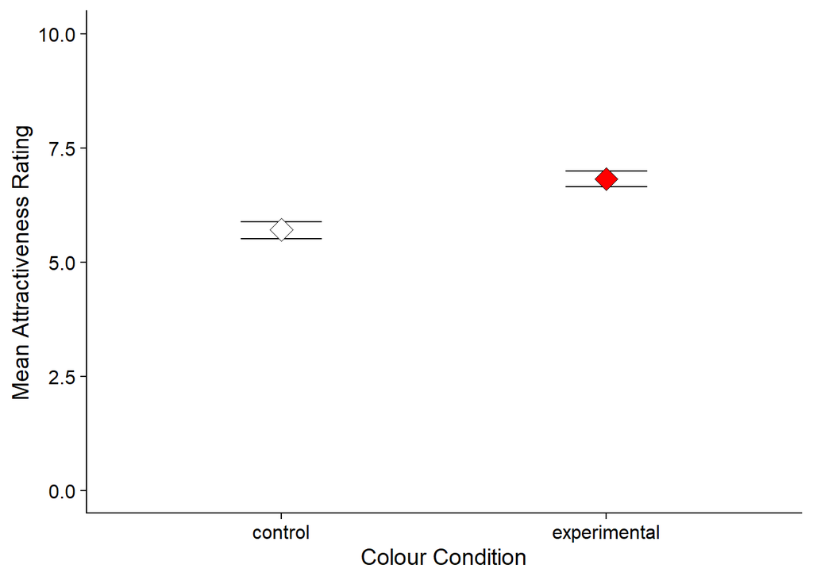

I used an independent measures t-test to examine the significance of my results. This test showed that the means in the two conditions were different (*M*<sub>diff</sub> = -1.12, 95% CI [-1.38, -0.85) and there was a significant difference in the mean attractiveness ratings of the red versus white colour groups (*t* (108) = -8.24, p<.001).

# Discussion

This experiment presents evidence to support the hypothesis that the colour red makes men appear more attractive to women. Therefore, this study gained similar results to those of the original (A. J. Elliot et al. 2010), which found significantly higher attractiveness ratings for men paired with the colour red, following the pattern of my research. This reinforces the likelihood of our hypothesis being true and increases the reliability of Elliot’s findings.

Other studies demonstrate similar findings, showing how red can increase physical and sexual attractiveness (Guéguen, 2012). Moreover, there is a wealth of research that focusses on the reverse, examining male ratings of female attractiveness regarding the colour red. This research also shows that red has a significant influence on desirability (Elliot & Niesta, 2008). Therefore, the colour red clearly has some impact on perceived attractiveness by men and women.

Empirical research categorises the colour red as intense, strong and exciting (Murray & Deabler 1957). Such suggestions may depict why it is prevalent in influencing higher attractiveness ratings and preference. Neto (2002) conducted a study that examined Lee’s model of the six “colours of love”, commonly known as love-styles (1988). Although Neto’s results did not provide support for other colours in this model, he did find that the colour red was significantly associated with desire and passion. This highlights the effect red has (more so than other colours) and illustrates its strong impact on individual’s perception, especially when it comes to desirability, attraction and preference.

However, it should be noted that not all research supports my hypothesis, with some studies finding no increase in preferences associated with the colour red (Peperkoorn, Roberts & Pollet, 2016). Therefore, it is possible that our findings were due to a confounding variable rather than the colour red itself. For instance, there may have been biases, within the two conditions, in the women’s preferences of men that could have altered the results. Also, since I used mean ratings to assess our data, results may have been affected by anomalies. Furthermore, different studies use different methods of associating colour with people (such as using red as a background versus an item of clothing). This difference may be the cause of increasing or decreasing desirability, meaning it is more complex than it may initially seem. In fact, it may be that several variables need to be considered.

To accommodate to this multifactorial approach, studies could investigate the differing effects colour has when used in different ways. For example, researchers could look at how use of red clothing versus a red background alters attractiveness ratings. In addition, follow up studies should be done to increase the number and variety of participants used. This would be worthwhile to validate results due to the number of contrasting findings that currently exist.

Clearly, the colour red has significant influences on our perceptions of attractiveness. This study showed an increase in attractiveness ratings for men who were paired with the colour red versus white. Although the results were significant, I would suggest that further research is necessary and if conducted, would have implications in marketing, dating websites and more.

# References

Elliot, Andrew J., Daniela Niesta Kayser, Tobias Greitemeyer, Stephanie Lichtenfeld, Richard H. Gramzow, Markus A. Maier, and Huijun Liu. 2010. ‘Red, Rank, and Romance in Women Viewing Men.’ Journal of Experimental Psychology: General 139 (3): 399–417. https://doi.org/10.1037/a0019689.

Guéguen, Nicolas. 2012. ‘Color and Women Attractiveness: When Red Clothed Women Are Perceived to Have More Intense Sexual Intent’. The Journal of Social Psychology 152 (3): 261–65. https://doi.org/10.1080/00224545.2011.605398.

Lee, J, M Barnes, and Sternberg. 1988. The Psychology of Love. Yale University Press.

Murray, David C., and Herdis L. Deabler. 1957. ‘Colors and Mood-Tones’. Journal of Applied Psychology 41 (5): 279–83. https://doi.org/10.1037/h0041425.

Neto, Félix. 2002. ‘Colors Associated with Styles of Love’. Perceptual and Motor Skills 94 (3_suppl): 1303–10. https://doi.org/10.2466/pms.2002.94.3c.1303.

Peperkoorn, L, Roberts, C, and Pollet, T. 2016. ‘Revisiting the Red Effect on Attractiveness and Sexual Receptivity: No Effect of the Color Red on Human Mate Preferences’. Sage 14 (4): 1–13. https://doi.org/10.1177/1474704916673841.